# Weather Forecast Source Comparison — RM 8.5 / Camp Polk

Maddee Rubenson (FlowWest)

2026-06-05

# Overview

This document compares three weather forecast data sources used in (or considered for) the RM 8.5 instream temperature forecasting workflow:

| Source | Description | Period | Access |
| --- | --- | --- | --- |
| **Open-Meteo (GFS Seamless)** | Archived GFS model runs via Open-Meteo Historical Forecast API. Used as inputs to the RF model. | 2019–present | `get_historical_forecast()` |
| **NWS API** | Official NWS gridded forecast for gridpoint PDT/35,57. Currently used for real-time predictions. | Logged May 2026–present | `get_nws_forecast()` |
| **dynamical.org GFS** | Raw GFS forecast and analysis archived via Icechunk/Zarr. Accessed via Python. | May 2021–present | Python `icechunk` + `xarray` |

**Location:** Whychus Creek RM 8.5 — 44.390278°N, -121.406792°W **Variables of interest:** Max 2m air temperature, min 2m air temperature, cloud cover

# 1. Open-Meteo GFS Seamless — Historical Forecasts

The `all_historical_forecasts` dataset contains archived GFS output from Open-Meteo at lead days 1, 3, and 7, plus ERA5 reanalysis as a baseline observation proxy. This is the training data used in the RF model.

```r
# all_historical_forecasts: valid_date, issue_date, lead_days, variable, value, units, lat, lon, type
hist_fc <- all_historical_forecasts |>
  mutate(
    lead_label = recode(as.character(lead_days), !!!LEAD_LABELS),
    lead_label = factor(lead_label, levels = names(LEAD_COLORS)),
    var_label  = recode(variable,
      "temperature_2m_max" = "Max Air Temp (°C)",
      "temperature_2m_min" = "Min Air Temp (°C)",
      "cloud_cover_mean"   = "Cloud Cover (%)"
    )
  )

hist_fc |>
  group_by(var_label, lead_label) |>
  summarise(
    start     = min(valid_date, na.rm = TRUE),
    end       = max(valid_date, na.rm = TRUE),
    n         = n(),
    n_missing = sum(is.na(value))
  ) |>
  kable(caption = "Open-Meteo historical forecast coverage by variable and lead time")
```

Open-Meteo historical forecast coverage by variable and lead time

| var_label | lead_label | start | end | n | n_missing |
| --- | --- | --- | --- | --- | --- |
| Cloud Cover (%) | ERA5 / GFS Analysis | 2011-01-01 | 2018-12-31 | 2922 | 0 |
| Cloud Cover (%) | Day 1 | 2019-01-01 | 2026-04-14 | 2661 | 0 |
| Cloud Cover (%) | Day 3 | 2019-01-01 | 2026-04-14 | 2661 | 0 |
| Cloud Cover (%) | Day 7 | 2019-01-01 | 2026-04-14 | 2661 | 0 |
| Max Air Temp (°C) | ERA5 / GFS Analysis | 2011-01-01 | 2018-12-31 | 2922 | 0 |
| Max Air Temp (°C) | Day 1 | 2019-01-01 | 2026-04-14 | 2661 | 0 |
| Max Air Temp (°C) | Day 3 | 2019-01-01 | 2026-04-14 | 2661 | 0 |
| Max Air Temp (°C) | Day 7 | 2019-01-01 | 2026-04-14 | 2661 | 0 |
| Min Air Temp (°C) | ERA5 / GFS Analysis | 2011-01-01 | 2018-12-31 | 2922 | 0 |
| Min Air Temp (°C) | Day 1 | 2019-01-01 | 2026-04-14 | 2661 | 0 |
| Min Air Temp (°C) | Day 3 | 2019-01-01 | 2026-04-14 | 2661 | 0 |
| Min Air Temp (°C) | Day 7 | 2019-01-01 | 2026-04-14 | 2661 | 0 |

## Seasonal mean by lead time

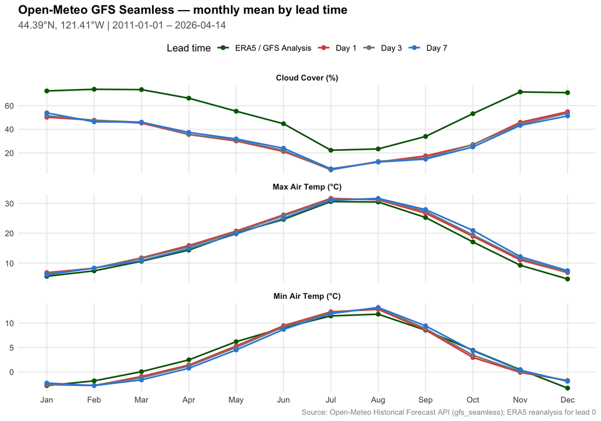

```r
plot_seasonal <- hist_fc |>
  filter(!is.na(value)) |>
  mutate(month = month(valid_date, label = TRUE)) |>
  group_by(month, var_label, lead_label) |>
  summarise(mean_value = mean(value, na.rm = TRUE), .groups = "drop")

ggplot(plot_seasonal, aes(x = month, y = mean_value, color = lead_label, group = lead_label)) +
  geom_line(linewidth = 0.9) +
  geom_point(size = 2) +
  facet_wrap(~var_label, scales = "free_y", ncol = 1) +
  scale_color_manual(values = LEAD_COLORS, name = "Lead time") +
  labs(
    title    = "Open-Meteo GFS Seamless — monthly mean by lead time",
    subtitle = paste0("44.39°N, 121.41°W | ", min(hist_fc$valid_date, na.rm=T), " – ", max(hist_fc$valid_date, na.rm=T)),
    x = NULL, y = NULL,
    caption  = "Source: Open-Meteo Historical Forecast API (gfs_seamless); ERA5 reanalysis for lead 0"
  ) +
  theme_fw()
```

## Forecast error vs. ERA5 baseline by lead time

```r
era5 <- hist_fc |>
  filter(lead_days == 0) |>
  select(valid_date, variable, obs = value)

bias_df <- hist_fc |>
  filter(lead_days > 0) |>
  inner_join(era5, by = c("valid_date", "variable")) |>
  mutate(error = value - obs)

bias_summary <- bias_df |>
  group_by(var_label, lead_label) |>
  summarise(
    bias = mean(error, na.rm = TRUE),
    mae  = mean(abs(error), na.rm = TRUE),
    rmse = sqrt(mean(error^2, na.rm = TRUE)),
    n    = n(),
    .groups = "drop"
  )

kable(bias_summary, digits = 2,
      caption = "Open-Meteo GFS vs. ERA5 — error metrics by variable and lead time")
```

Open-Meteo GFS vs. ERA5 — error metrics by variable and lead time

[output not shown]

# 2. NWS Real-Time Forecast Log

The NWS API (gridpoint PDT/35,57) is pulled daily by `run-daily-forecast.R`. Results are appended to `output/nws-forecasts-log.csv`. This section summarises the logged NWS forecasts and current real-time forecast.

```r
nws_log_path <- here("output", "nws-forecasts-log.csv")

nws_log <- read_csv(nws_log_path, show_col_types = FALSE) |>
  mutate(
    run_date      = as.Date(run_date),
    forecast_date = as.Date(forecast_date),
    lead_days     = as.integer(lead_days)
  )

cat(sprintf("NWS log: %d rows | %s to %s\n",
    nrow(nws_log), min(nws_log$run_date), max(nws_log$run_date)))
```

```
## NWS log: 2208 rows | 2026-05-04 to 2026-06-02
```

```r
# Pull live NWS forecast — gracefully fall back to log if API is unavailable
nws_live <- tryCatch({
  bind_rows(
    get_nws_forecast(GRIDPT, "maxTemperature") |> mutate(source = "NWS live"),
    get_nws_forecast(GRIDPT, "minTemperature") |> mutate(source = "NWS live"),
    get_nws_forecast(GRIDPT, "skyCover")       |> mutate(source = "NWS live")
  )
}, error = function(e) {
  message("NWS API unavailable: ", e$message)
  NULL
})

if (!is.null(nws_live)) {
  cat(sprintf("Live NWS pull successful — %d rows, variables: %s\n",
      nrow(nws_live), paste(unique(nws_live$variable), collapse = ", ")))
} else {
  cat("Using forecast log for NWS comparison.\n")
}
```

```
## Live NWS pull successful — 78 rows, variables: maxTemperature, minTemperature, skyCover
```

## Logged NWS forecasts — daily max & min temperature

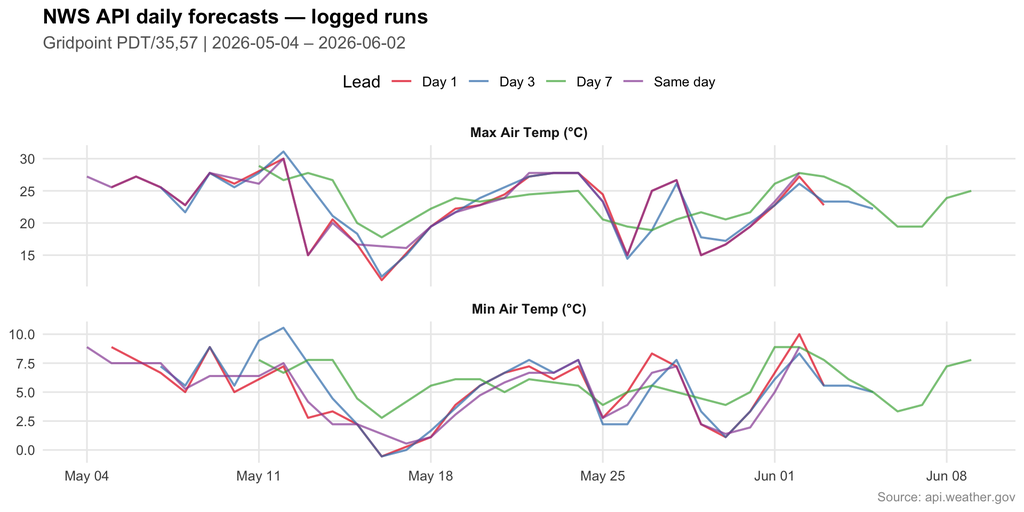

```r
nws_daily <- nws_log |>
  filter(variable %in% c("maxTemperature", "minTemperature")) |>
  group_by(run_date, forecast_date, lead_days, variable) |>
  summarise(value = mean(value, na.rm = TRUE), .groups = "drop") |>
  mutate(
    var_label  = recode(variable,
      "maxTemperature" = "Max Air Temp (°C)",
      "minTemperature" = "Min Air Temp (°C)"
    ),
    lead_label = case_when(
      lead_days == 0 ~ "Same day",
      lead_days == 1 ~ "Day 1",
      lead_days == 3 ~ "Day 3",
      lead_days == 7 ~ "Day 7",
      TRUE           ~ paste0("Day ", lead_days)
    )
  )

# Summarise to one value per forecast_date × lead × variable (mean across run dates)
nws_fc_summary <- nws_daily |>
  group_by(forecast_date, lead_days, lead_label, var_label) |>
  summarise(value = mean(value, na.rm = TRUE), .groups = "drop") |>
  filter(lead_days %in% c(0, 1, 3, 7))

ggplot(nws_fc_summary, aes(x = forecast_date, y = value,
                            color = lead_label, group = lead_label)) +
  geom_line(alpha = 0.7, linewidth = 0.7) +
  facet_wrap(~var_label, ncol = 1, scales = "free_y") +
  scale_color_brewer(palette = "Set1", name = "Lead") +
  labs(
    title    = "NWS API daily forecasts — logged runs",
    subtitle = paste0("Gridpoint ", GRIDPT, " | ", min(nws_daily$run_date), " – ", max(nws_daily$run_date)),
    x = NULL, y = NULL,
    caption  = "Source: api.weather.gov"
  ) +
  theme_fw()
```

## Current live NWS forecast

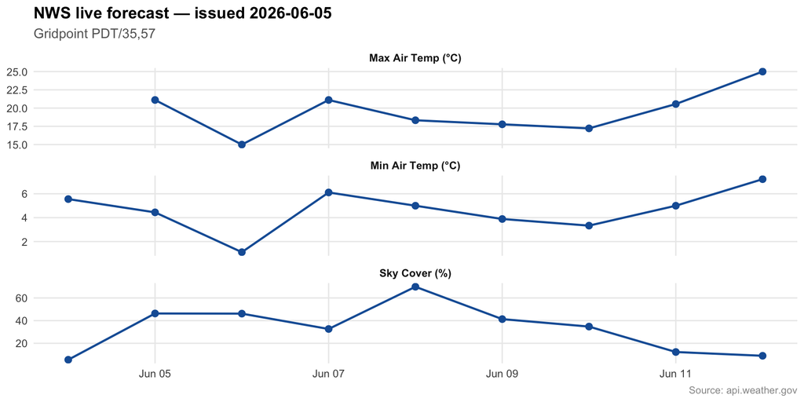

```r
if (!is.null(nws_live)) {
  nws_live |>
    filter(variable %in% c("maxTemperature", "minTemperature", "skyCover")) |>
    mutate(
      forecast_date = as.Date(datetime, tz = "America/Los_Angeles"),
      var_label = recode(variable,
        "maxTemperature" = "Max Air Temp (°C)",
        "minTemperature" = "Min Air Temp (°C)",
        "skyCover"       = "Sky Cover (%)"
      )
    ) |>
    group_by(forecast_date, var_label) |>
    summarise(value = mean(value, na.rm = TRUE), .groups = "drop") |>
    ggplot(aes(x = forecast_date, y = value)) +
    geom_line(color = "#185FA5", linewidth = 0.9) +
    geom_point(color = "#185FA5", size = 2.5) +
    facet_wrap(~var_label, ncol = 1, scales = "free_y") +
    labs(
      title    = paste("NWS live forecast — issued", Sys.Date()),
      subtitle = paste0("Gridpoint ", GRIDPT),
      x = NULL, y = NULL,
      caption  = "Source: api.weather.gov"
    ) +
    theme_fw()
} else {
  cat("Live NWS forecast unavailable — skipping plot.\n")
}
```

# 3. dynamical.org GFS — Python Access

dynamical.org archives the raw NOAA GFS model output in Icechunk/Zarr format on AWS S3. Two datasets are relevant:

- **GFS Forecast** (`noaa-gfs-forecast`): initialized every 6 h, 0–384 h lead, from 2021-05-01 onward
- **GFS Analysis** (`noaa-gfs-analysis`): analysis-time GFS fields (no lead time), 2021-05-01 onward

Both datasets include `temperature_2m`, `maximum_temperature_2m`, `minimum_temperature_2m`, and `total_cloud_cover_atmosphere` at 0.25° resolution.

> **Zarr store:** `s3://dynamical-noaa-gfs/noaa-gfs-forecast/v0.2.7.icechunk/`

```python
import warnings
warnings.filterwarnings("ignore")

import pandas as pd
import numpy as np
from datetime import datetime, timedelta, timezone

# Try dynamical package first, fall back to icechunk + xarray
DYN_AVAILABLE = False
ICE_AVAILABLE = False

try:
    import dynamical
    DYN_AVAILABLE = True
    print("dynamical package available")
except ImportError:
    print("dynamical not found — trying icechunk + xarray")
```

```
## dynamical not found — trying icechunk + xarray
```

```python
try:
    import icechunk
    import xarray as xr
    ICE_AVAILABLE = True
    print("icechunk + xarray available")
except ImportError:
    print("icechunk not available")
```

```
## icechunk not available
```

```python
print(f"DYN_AVAILABLE={DYN_AVAILABLE}, ICE_AVAILABLE={ICE_AVAILABLE}")
```

```
## DYN_AVAILABLE=False, ICE_AVAILABLE=False
```

```python
import pandas as pd
import numpy as np

# Target location
LAT = 44.390278
LON = -121.406792  # xarray typically wants 0-360; GFS uses -180 to 180

dyn_fcst_df  = pd.DataFrame()
dyn_anal_df  = pd.DataFrame()

def open_gfs_forecast():
    """Open GFS forecast via dynamical or icechunk, return xarray Dataset."""
    if DYN_AVAILABLE:
        return dynamical.open_dataset("noaa-gfs-forecast")
    elif ICE_AVAILABLE:
        storage = icechunk.StorageConfig.s3_anonymous(
            bucket="dynamical-noaa-gfs",
            prefix="noaa-gfs-forecast/v0.2.7.icechunk/",
            region="us-east-1"
        )
        repo = icechunk.Repository.open(storage=storage)
        return xr.open_zarr(repo.readonly_session(), consolidated=False)
    else:
        return None

def open_gfs_analysis():
    """Open GFS analysis via dynamical or icechunk, return xarray Dataset."""
    if DYN_AVAILABLE:
        return dynamical.open_dataset("noaa-gfs-analysis")
    elif ICE_AVAILABLE:
        # Fetch analysis STAC URL for the correct version
        import requests
        stac = requests.get(
            "https://stac.dynamical.org/noaa-gfs-analysis/collection.json",
            timeout=10
        ).json()
        href = stac["assets"]["zarr"]["href"]
        storage = icechunk.StorageConfig.s3_anonymous(
            bucket=href.split("/")[2],
            prefix="/".join(href.split("/")[3:]),
            region="us-east-1"
        )
        repo = icechunk.Repository.open(storage=storage)
        return xr.open_zarr(repo.readonly_session(), consolidated=False)
    else:
        return None

# ── GFS Forecast ────────────────────────────────────────────────────────────
if DYN_AVAILABLE or ICE_AVAILABLE:
    try:
        import xarray as xr
        ds_fcst = open_gfs_forecast()

        if ds_fcst is not None:
            print("GFS Forecast dataset opened")
            print("Variables:", list(ds_fcst.data_vars)[:8])

            # Pull the most recent 60 days of 00Z init runs at lead 1d, 3d, 7d
            # init_time dimension, lead_time dimension
            today_utc = pd.Timestamp.now(tz="UTC").floor("D")
            start_init = today_utc - pd.Timedelta(days=60)

            # Slice to our window and nearest point
            point = ds_fcst.sel(
                latitude=LAT, longitude=LON, method="nearest"
            )

            # Subset init times
            init_times = pd.date_range(start=start_init, end=today_utc, freq="D")
            init_times_avail = [t for t in init_times
                                if t in point.init_time.values]

            rows = []
            vars_want = {
                "maximum_temperature_2m" : "temperature_2m_max",
                "minimum_temperature_2m" : "temperature_2m_min",
                "total_cloud_cover_atmosphere": "cloud_cover_mean"
            }
            for lead_days in [1, 3, 7]:
                lt = pd.Timedelta(days=lead_days)
                for it in init_times_avail[:30]:  # limit to 30 init times for speed
                    try:
                        snap = point.sel(init_time=it, lead_time=lt, method="nearest")
                        valid_dt = it + lt
                        for raw_var, clean_var in vars_want.items():
                            if raw_var in snap:
                                val = float(snap[raw_var].values)
                                # Convert K → °C for temperature
                                if "temperature" in raw_var and val > 100:
                                    val -= 273.15
                                rows.append({
                                    "source"    : "dynamical_gfs_forecast",
                                    "init_date" : it.date(),
                                    "valid_date": valid_dt.date(),
                                    "lead_days" : lead_days,
                                    "variable"  : clean_var,
                                    "value"     : round(val, 3)
                                })
                    except Exception:
                        pass

            dyn_fcst_df = pd.DataFrame(rows)
            print(f"GFS Forecast: {len(dyn_fcst_df)} rows")
        else:
            print("GFS Forecast dataset is None")

    except Exception as e:
        print(f"GFS Forecast fetch failed: {e}")
else:
    print("No Python data access packages available — skipping dynamical.org pull")
    print("Install with: pip install dynamical  OR  pip install icechunk xarray")
```

```
## No Python data access packages available — skipping dynamical.org pull
## Install with: pip install dynamical  OR  pip install icechunk xarray
```

```python
# ── GFS Analysis ─────────────────────────────────────────────────────────────
if DYN_AVAILABLE or ICE_AVAILABLE:
    try:
        import xarray as xr
        ds_anal = open_gfs_analysis()

        if ds_anal is not None:
            print("GFS Analysis dataset opened")

            today_utc = pd.Timestamp.now(tz="UTC").floor("D")
            start_anal = today_utc - pd.Timedelta(days=60)

            point_anal = ds_anal.sel(
                latitude=LAT, longitude=LON, method="nearest"
            )

            # time dimension (not init_time × lead_time)
            time_slice = point_anal.sel(time=slice(start_anal, today_utc))

            rows_a = []
            vars_want = {
                "maximum_temperature_2m" : "temperature_2m_max",
                "minimum_temperature_2m" : "temperature_2m_min",
                "total_cloud_cover_atmosphere": "cloud_cover_mean"
            }
            # Resample to daily
            for raw_var, clean_var in vars_want.items():
                if raw_var not in time_slice:
                    continue
                agg = "max" if "maximum" in raw_var else (
                      "min" if "minimum" in raw_var else "mean")
                daily = getattr(time_slice[raw_var].resample(time="1D"), agg)()
                vals = daily.compute().values.tolist()
                dates = [pd.Timestamp(t).date() for t in daily.time.values]
                for d, v in zip(dates, vals):
                    if v is not None and not np.isnan(v):
                        fval = float(v)
                        if "temperature" in raw_var and fval > 100:
                            fval -= 273.15
                        rows_a.append({
                            "source"    : "dynamical_gfs_analysis",
                            "valid_date": d,
                            "variable"  : clean_var,
                            "value"     : round(fval, 3)
                        })

            dyn_anal_df = pd.DataFrame(rows_a)
            print(f"GFS Analysis: {len(dyn_anal_df)} rows")

    except Exception as e:
        print(f"GFS Analysis fetch failed: {e}")
```

```r
# Pull Python DataFrames into R
dyn_fcst <- tryCatch(py$dyn_fcst_df, error = function(e) NULL)
dyn_anal <- tryCatch(py$dyn_anal_df, error = function(e) NULL)

# Convert to tibble and fix types
clean_dyn_df <- function(df) {
  if (is.null(df) || nrow(df) == 0) return(NULL)
  df |>
    as_tibble() |>
    mutate(across(any_of(c("valid_date", "init_date")), as.Date))
}

dyn_fcst <- clean_dyn_df(dyn_fcst)
dyn_anal <- clean_dyn_df(dyn_anal)

cat(sprintf("dynamical.org GFS Forecast: %d rows\n", if (is.null(dyn_fcst)) 0L else nrow(dyn_fcst)))
```

```
## dynamical.org GFS Forecast: 0 rows
```

```r
cat(sprintf("dynamical.org GFS Analysis: %d rows\n", if (is.null(dyn_anal)) 0L else nrow(dyn_anal)))
```

```
## dynamical.org GFS Analysis: 0 rows
```

```r
# If Python packages unavailable, note it
if (is.null(dyn_fcst)) {
  cat("\nNote: dynamical.org data could not be fetched.\n")
  cat("Install Python packages to enable this section:\n")
  cat("  pip install dynamical\n")
  cat("  OR\n")
  cat("  pip install icechunk xarray\n")
}
```

```
##
## Note: dynamical.org data could not be fetched.
## Install Python packages to enable this section:
##   pip install dynamical
##   OR
##   pip install icechunk xarray
```

## dynamical.org GFS forecast — recent 60 days

```r
if (!is.null(dyn_fcst) && nrow(dyn_fcst) > 0) {
  dyn_fcst |>
    mutate(
      var_label  = recode(variable,
        "temperature_2m_max"  = "Max Air Temp (°C)",
        "temperature_2m_min"  = "Min Air Temp (°C)",
        "cloud_cover_mean"    = "Cloud Cover (%)"
      ),
      lead_label = paste("Day", lead_days)
    ) |>
    ggplot(aes(x = valid_date, y = value, color = lead_label, group = lead_label)) +
    geom_line(alpha = 0.8, linewidth = 0.8) +
    geom_point(size = 1.5, alpha = 0.6) +
    facet_wrap(~var_label, ncol = 1, scales = "free_y") +
    scale_color_brewer(palette = "Dark2", name = "Lead") +
    labs(
      title    = "dynamical.org GFS Forecast — recent 60 days",
      subtitle = paste0(LAT, "°N, ", abs(LON), "°W | lead_time = 1d, 3d, 7d"),
      x = NULL, y = NULL,
      caption  = "Source: dynamical.org noaa-gfs-forecast (s3://dynamical-noaa-gfs)"
    ) +
    theme_fw()
} else {
  cat("dynamical.org GFS forecast data not available for plotting.\n")
}
```

```
## dynamical.org GFS forecast data not available for plotting.
```

## dynamical.org GFS analysis — recent 60 days

```r
if (!is.null(dyn_anal) && nrow(dyn_anal) > 0) {
  dyn_anal |>
    mutate(
      var_label = recode(variable,
        "temperature_2m_max"  = "Max Air Temp (°C)",
        "temperature_2m_min"  = "Min Air Temp (°C)",
        "cloud_cover_mean"    = "Cloud Cover (%)"
      )
    ) |>
    ggplot(aes(x = valid_date, y = value)) +
    geom_line(color = "darkgreen", linewidth = 0.9) +
    geom_point(color = "darkgreen", size = 1.5) +
    facet_wrap(~var_label, ncol = 1, scales = "free_y") +
    labs(
      title    = "dynamical.org GFS Analysis — recent 60 days",
      subtitle = paste0(LAT, "°N, ", abs(LON), "°W"),
      x = NULL, y = NULL,
      caption  = "Source: dynamical.org noaa-gfs-analysis (s3://dynamical-noaa-gfs)"
    ) +
    theme_fw()
} else {
  cat("dynamical.org GFS analysis data not available for plotting.\n")
}
```

```
## dynamical.org GFS analysis data not available for plotting.
```

# 4. Cross-Source Comparison

## 4a. NWS vs. dynamical.org GFS — overlapping period

The NWS API returns the official forecast with MOS post-processing and human adjustments. The dynamical.org GFS forecast is raw model output. Both should be similar for the same valid date and lead, but differences reflect NWS post-processing.

```
## dynamical.org data unavailable — NWS vs. GFS comparison skipped.
```

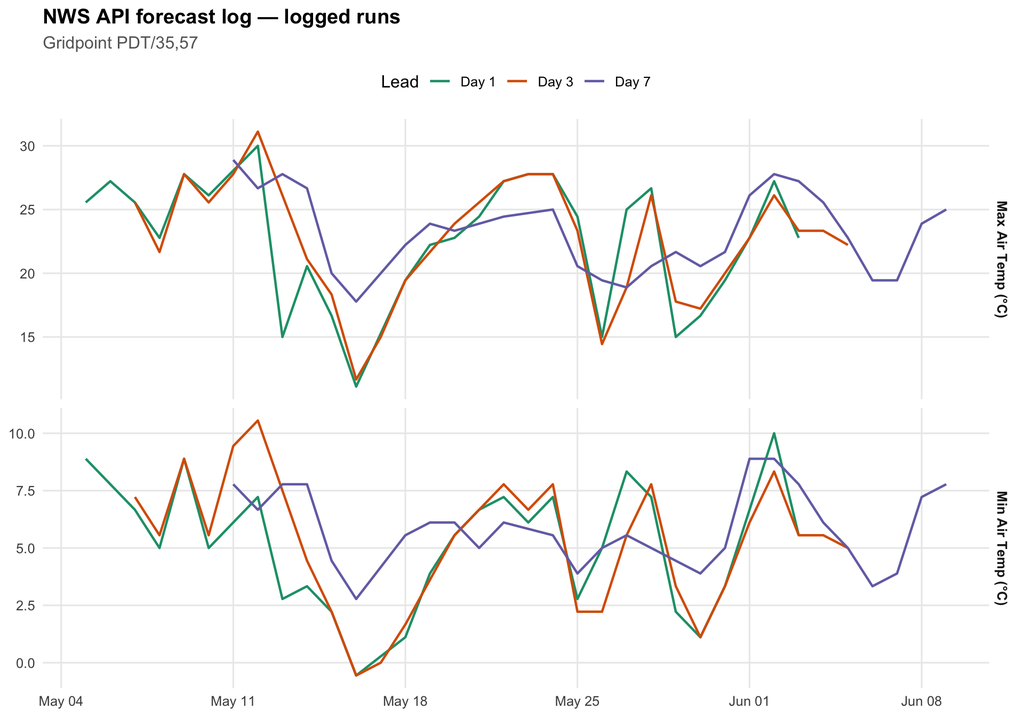

```r
if (!is.null(dyn_fcst) && nrow(dyn_fcst) > 0) {

  # Standardise NWS log to same schema
  nws_std <- nws_log |>
    filter(variable %in% c("maxTemperature", "minTemperature")) |>
    group_by(run_date, forecast_date, lead_days, variable) |>
    summarise(value = mean(value, na.rm = TRUE), .groups = "drop") |>
    mutate(
      variable  = recode(variable,
        "maxTemperature" = "temperature_2m_max",
        "minTemperature" = "temperature_2m_min"
      ),
      source = "NWS API (weather.gov)"
    ) |>
    rename(valid_date = forecast_date, init_date = run_date)

  # Standardise dynamical GFS forecast
  dyn_std <- dyn_fcst |>
    filter(variable %in% c("temperature_2m_max", "temperature_2m_min")) |>
    mutate(source = "dynamical.org GFS forecast") |>
    rename(init_date = init_date)

  combined <- bind_rows(nws_std, dyn_std) |>
    filter(lead_days %in% c(1, 3, 7)) |>
    mutate(
      var_label  = recode(variable,
        "temperature_2m_max" = "Max Air Temp (°C)",
        "temperature_2m_min" = "Min Air Temp (°C)"
      ),
      lead_label = paste("Day", lead_days)
    )

  # Need one value per source × valid_date × lead × variable
  combined_daily <- combined |>
    group_by(source, valid_date, lead_days, lead_label, var_label) |>
    summarise(value = mean(value, na.rm = TRUE), .groups = "drop")

  ggplot(combined_daily,
         aes(x = valid_date, y = value, color = source, group = source)) +
    geom_line(alpha = 0.8, linewidth = 0.8) +
    facet_grid(var_label ~ lead_label, scales = "free_y") +
    scale_color_manual(
      values = c("NWS API (weather.gov)"       = "#C93312",
                 "dynamical.org GFS forecast"  = "#378ADD"),
      name = NULL
    ) +
    labs(
      title    = "NWS API vs. dynamical.org GFS — temperature forecast comparison",
      subtitle = paste0("Lead = 1, 3, 7 days | Overlapping period"),
      x = NULL, y = NULL,
      caption  = "NWS = GFS + MOS post-processing; dynamical.org = raw GFS output"
    ) +
    theme_fw()

} else {
  cat("dynamical.org data unavailable — NWS vs. GFS comparison skipped.\n")

  # Still show NWS log summary across run dates
  nws_log |>
    filter(variable %in% c("maxTemperature", "minTemperature"),
           lead_days %in% c(1, 3, 7)) |>
    group_by(forecast_date, lead_days, variable) |>
    summarise(value = mean(value, na.rm = TRUE), .groups = "drop") |>
    mutate(
      var_label  = recode(variable,
        "maxTemperature" = "Max Air Temp (°C)",
        "minTemperature" = "Min Air Temp (°C)"
      ),
      lead_label = paste("Day", lead_days)
    ) |>
    ggplot(aes(x = forecast_date, y = value, color = lead_label)) +
    geom_line(linewidth = 0.8) +
    facet_grid(var_label ~ ., scales = "free_y") +
    scale_color_brewer(palette = "Dark2", name = "Lead") +
    labs(
      title    = "NWS API forecast log — logged runs",
      subtitle = paste0("Gridpoint ", GRIDPT),
      x = NULL, y = NULL
    ) +
    theme_fw()
}
```

## 4b. NWS vs. dynamical.org — difference scatter plot

```r
if (!is.null(dyn_fcst) && nrow(dyn_fcst) > 0) {

  nws_daily_tmax <- nws_log |>
    filter(variable == "maxTemperature") |>
    group_by(forecast_date, lead_days) |>
    summarise(nws_tmax = mean(value, na.rm = TRUE), .groups = "drop")

  dyn_daily_tmax <- dyn_fcst |>
    filter(variable == "temperature_2m_max") |>
    group_by(valid_date, lead_days) |>
    summarise(dyn_tmax = mean(value, na.rm = TRUE), .groups = "drop")

  joined <- inner_join(
    nws_daily_tmax |> rename(valid_date = forecast_date),
    dyn_daily_tmax,
    by = c("valid_date", "lead_days")
  ) |>
    filter(lead_days %in% c(1, 3, 7)) |>
    mutate(lead_label = paste("Day", lead_days))

  if (nrow(joined) > 3) {
    ggplot(joined, aes(x = dyn_tmax, y = nws_tmax, color = lead_label)) +
      geom_abline(slope = 1, intercept = 0, linetype = "dashed", color = "grey50") +
      geom_point(size = 2.5, alpha = 0.7) +
      geom_smooth(method = "lm", se = FALSE, linewidth = 0.8) +
      facet_wrap(~lead_label) +
      scale_color_brewer(palette = "Dark2", guide = "none") +
      labs(
        title   = "NWS vs. dynamical.org GFS — max temperature scatter",
        x       = "dynamical.org GFS Tmax (°C)",
        y       = "NWS API Tmax (°C)",
        caption = "Dashed line = 1:1; points above line = NWS warmer than raw GFS"
      ) +
      theme_fw()
  } else {
    cat("Insufficient overlapping data for scatter plot.\n")
  }

} else {
  cat("dynamical.org data unavailable — scatter plot skipped.\n")
}
```

```
## dynamical.org data unavailable — scatter plot skipped.
```

## 4c. Open-Meteo GFS vs. dynamical.org GFS — model alignment

Open-Meteo (`gfs_seamless`) and dynamical.org both archive GFS output but with different processing pipelines. For the overlapping period (May 2021 onward), we expect similar but not identical values due to spatial downscaling differences.

```r
if (!is.null(dyn_fcst) && nrow(dyn_fcst) > 0) {

  # Open-Meteo historical at lead 1, 3, 7 — post-2021
  om_recent <- hist_fc |>
    filter(lead_days %in% c(1, 3, 7),
           valid_date >= as.Date("2021-05-01"),
           variable %in% c("temperature_2m_max", "temperature_2m_min", "cloud_cover_mean")) |>
    mutate(source = "Open-Meteo GFS seamless") |>
    select(source, valid_date, lead_days, variable, value)

  dyn_std2 <- dyn_fcst |>
    filter(variable %in% c("temperature_2m_max", "temperature_2m_min", "cloud_cover_mean")) |>
    mutate(source = "dynamical.org GFS forecast") |>
    select(source, valid_date, lead_days, variable, value)

  both <- bind_rows(om_recent, dyn_std2) |>
    filter(lead_days %in% c(1, 3, 7)) |>
    mutate(
      var_label  = recode(variable,
        "temperature_2m_max" = "Max Air Temp (°C)",
        "temperature_2m_min" = "Min Air Temp (°C)",
        "cloud_cover_mean"   = "Cloud Cover (%)"
      ),
      lead_label = paste("Day", lead_days)
    ) |>
    group_by(source, valid_date, lead_days, lead_label, var_label) |>
    summarise(value = mean(value, na.rm = TRUE), .groups = "drop")

  ggplot(both, aes(x = valid_date, y = value, color = source)) +
    geom_line(alpha = 0.7, linewidth = 0.7) +
    facet_grid(var_label ~ lead_label, scales = "free_y") +
    scale_color_manual(
      values = c("Open-Meteo GFS seamless"     = "#888780",
                 "dynamical.org GFS forecast"  = "#378ADD"),
      name = NULL
    ) +
    labs(
      title    = "Open-Meteo GFS seamless vs. dynamical.org GFS — model alignment",
      subtitle = "Same underlying model, different processing pipelines",
      x = NULL, y = NULL,
      caption  = "Differences reflect spatial downscaling and potential ECMWF blending in Open-Meteo seamless"
    ) +
    theme_fw()

} else {
  cat("dynamical.org data unavailable — Open-Meteo vs. dynamical.org comparison skipped.\n")

  # Show Open-Meteo alone for the recent period
  hist_fc |>
    filter(lead_days %in% c(1, 3, 7),
           valid_date >= as.Date("2021-05-01"),
           variable %in% c("temperature_2m_max", "temperature_2m_min")) |>
    mutate(month = month(valid_date, label = TRUE)) |>
    group_by(month, var_label, lead_label) |>
    summarise(mean_value = mean(value, na.rm = TRUE), .groups = "drop") |> invisible()

  # fallback plot if dyn not available - already shown above, skip
  cat("Open-Meteo data shown in Section 1.\n")
}
```

```
## dynamical.org data unavailable — Open-Meteo vs. dynamical.org comparison skipped.
## Open-Meteo data shown in Section 1.
```

# 5. Forecast Skill by Lead Time

```r
skill <- bias_df |>
  group_by(var_label, lead_days) |>
  summarise(
    n        = n(),
    bias     = round(mean(error, na.rm = TRUE), 2),
    mae      = round(mean(abs(error), na.rm = TRUE), 2),
    rmse     = round(sqrt(mean(error^2, na.rm = TRUE)), 2),
    r        = tryCatch(round(cor(value, obs, use = "complete.obs"), 3), error = function(e) NA_real_),
    .groups  = "drop"
  )

kable(skill, caption = "GFS forecast skill vs. ERA5 baseline by lead time (Open-Meteo archive)",
      col.names = c("Variable", "Lead (days)", "N", "Bias (°C)", "MAE (°C)", "RMSE (°C)", "r"))
```

GFS forecast skill vs. ERA5 baseline by lead time (Open-Meteo archive)

[output not shown]

```r
skill_temp <- skill |> filter(grepl("Temp", var_label))
if (nrow(skill_temp) > 0) {
  skill_temp |>
    pivot_longer(c(bias, mae, rmse), names_to = "metric", values_to = "val") |>
    mutate(metric = factor(metric, levels = c("bias", "mae", "rmse"),
                            labels = c("Bias", "MAE", "RMSE"))) |>
    ggplot(aes(x = lead_days, y = val, color = var_label, group = var_label)) +
    geom_line(linewidth = 0.9) +
    geom_point(size = 3) +
    facet_wrap(~metric, scales = "free_y") +
    scale_x_continuous(breaks = c(1, 3, 7)) +
    scale_color_manual(values = c("#C93312", "#378ADD"), name = NULL) +
    labs(
      title   = "Forecast error metrics by lead time",
      x       = "Lead time (days)", y = NULL,
      caption = "Source: Open-Meteo Historical Forecast API vs. ERA5 reanalysis"
    ) +
    theme_fw()
} else {
  cat("No ERA5 baseline available — forecast skill plot skipped.\n")
}
```

```
## No ERA5 baseline available — forecast skill plot skipped.
```

# 6. Source Summary and Recommendations

Weather forecast source comparison

| Source | Data type | Temporal coverage | Lead times | Resolution | Access | Notes |
| --- | --- | --- | --- | --- | --- | --- |
| Open-Meteo GFS seamless | Historical archive | 2019–present | 1, 3, 7 d | ~25 km | R: `get_historical_forecast()` | ERA5 baseline pre-2019; blends ECMWF at longer leads |
| NWS API (weather.gov) | Real-time forecast | Logged May 2026+ | 0–7+ d | ~2.5 km | R: `get_nws_forecast()` | MOS post-processing; human adjustments |
| dynamical.org GFS forecast | Real-time + archive | May 2021–present | 0–384 h | ~25 km | Python: `dynamical` or `icechunk+xarray` | Raw GFS; hourly → 3-hourly |
| dynamical.org GFS analysis | Analysis (no lead) | May 2021–present | n/a | ~25 km | Python: `dynamical` or `icechunk+xarray` | Best available GFS-grid observation proxy |

**Key differences between sources:**

- **NWS vs. raw GFS:** NWS applies MOS bias correction and human edits, particularly for temperature. Expect NWS to be 1–3°C warmer/cooler than raw GFS on any given day. For real-time forecasting, NWS is operationally tested and locally calibrated — preferred for the current RF model.
- **Open-Meteo vs. dynamical.org GFS:** Both derive from GFS but Open-Meteo applies statistical downscaling and blends ECMWF at lead > ~5 days. Dynamical.org is closer to the raw GFS grid output. The Open-Meteo archive is suitable for model training; dynamical.org’s analysis product provides a useful cross-check.
- **Temporal depth:** For training the RF model, Open-Meteo (2019–present) provides the longest GFS-archive record. ERA5 extends coverage to 2011 at the cost of swapping from a forecast to a reanalysis product.

**Recommendation for RM 8.5 model:** - Continue using `get_nws_forecast()` (NWS API) for real-time predictions — it is operationally reliable and already integrated. - Use Open-Meteo GFS seamless (`get_historical_forecast()`) for training data — longest consistent archive. - Use dynamical.org GFS analysis as a secondary validation benchmark for recent years (2021–present) where both sources overlap.